# Twin Cities R User Group: Pricing Sentiment Analysis

Armin Kakas

Wednesday, October 14, 2015

# Objective

Written customer comments and reviews on company websites can be a genuine expression of their sentiment on various product attributes. Retailer websites provide a wealth of information related to this, and with some simple text analytics, we can evaluate:  
- How customers feel about a product’s price over time?  
- What customer think about product quality, functionality, etc.?  
- How recent shifts in pricing strategy influenced consumer price perception?  
- How recent shifts in advertising strategy influenced consumer perception of quality?  
- How to segment products based on text mining outcomes?  
- What pricing strategies to further pursue based on our text analysis *(elasticity and revenue or margin based strategies no longer suffice)*?

I believe that NLP is a much more powerful way of gauging what customers think and feel about **pricing** as opposed to consumer satisfaction scores (or **NPS scores** for that matter), which are inherently biased for purchasers vs. non-purchasers.

If you have the time, I encourage you to read the code, and make suggestions on how to better improve the methodology of evaluating pricing sentiment (which, admittedly, is quite basic below).

## Our data

Obtained product reviews and ratings for appr. 100 items. I used Python’s **Beautiful Soup** package that works quite elegantly. The attributes are:  
1. **date**: date of the review  
2. **rating**: the rating the customer gave to the particular item on a particular day  
3. **comment**: the actual text of the written customer comment  
4. **wmt_product_name**: the name of the product displayed on the Walmart website  
5. **wmt_product_id**: the Walmart product id associated with the product

**Data and code can be found on https://github.com/KakasA09/TCRUGOct2015**

## Keywords

These are pricing keyword (see below). We will parse the Walmart customer comments to see if they include one of these keywords. It is certainly not a bullet-proof way of delineating **pricing-related** comments, and robust NLP methods are needed - *pained to admit, but Python is best for that*.

```r
load('comments.Rda')
load('pricing_sentences.Rda')
keywords <- read.csv('pricing_keywords.csv')
keywords <- as.character(keywords$keyword)

keywords[1:5]
```

[1] “bargain” “bill” “bounty” “charge” “cheap”

## Parsing pricing-related comments

In the below, we are doing three things:  
1. Only keep the customer comments that contain one of our **pricing keywords**.  
2. Split the comments into sentences using the **qdap** package’s **sentSplit** function. (imagine splitting a comment comprised of 5 sentences, thus 1 row of data becoming 5 rows).  
3. We repeate the earlier exercise by taking a look at our sentences*, and only keeping the ones that have one or more of the **pricing keywords**. We are, in essence, keeping **pricing-related sentences** only. Keep in mind, we still retained the product, date and rating fields.

Now, ideally we would go a step further, and keep pricing-related **ngrams** only. Reason is simple: a customer can make a long statement (sentence), and while the overall sentiment of the statement may be highly negative, her sentiment about the product’s price could have been quite positive..e.g.: *“Product quality was awful, but Walmart’s prices are the best!”*

```r
################# Don't run this
#parse out pricing only comments
options(width = 1000)
comments = tbl_df(comments) %>% select(wmt_product_id, date, comment)
comments = comments[complete.cases(comments$comment),]

pricing_comments1 <- comments  %>% mutate(keyword_present = grepl(paste(keywords,collapse=" | "), comment, ignore.case = TRUE)) %>%
    filter(keyword_present == TRUE) %>% select(-keyword_present)

pricing_comments1 = data.frame(pricing_comments1)

#split comments to form unique sentences
pricing_sentences = sentSplit(pricing_comments1, "comment")

#save(pricing_sentences, file = 'pricing_sentences.Rda')
#################


load('pricing_sentences.Rda')

pricing_sentences <- tbl_df(pricing_sentences)  %>%
    mutate(keyword_present = grepl(paste(keywords,collapse="|"), comment, ignore.case = TRUE)) %>%
    filter(keyword_present == TRUE) %>%
    select(wmt_product_id, date, comment)


#ensure there is complete data
pricing_sentences <- na.omit(pricing_sentences)
```

## Creating customized dictionaries for negative, positive, negation words, amplifiers and de-amplifiers

Since our approach for measuring customers’ **pricing sentiment score** is a slightly enhanced version of **lexicon-based scoring**, we will make it a bit more robust by adding industry-specific terms.

## Sentiment scoring with parallelization

In the below, we will use the versatile **qdap** package to formulate **sentiment polarity scores** (constrained between +1 and -1). **Qdap** enables us to score our data by grouping factors: in our case by **product** and by **date**.

```r
wmt_product_list = unique(pricing_sentences$wmt_product_id)

library(doMC)
registerDoMC(cores = detectCores()-2)

pricing_polarity_scores <- foreach(a = 1:length(wmt_product_list),.combine = 'rbind',
                                   .packages = c('dplyr', 'qdap', 'tidyr')) %dopar% {

    pricing_sentences_small <- pricing_sentences %>%
                    filter(wmt_product_id == wmt_product_list[a])

    pricing_polarity_small = with(pricing_sentences_small,
              polarity(comment, polarity.frame = pos_negative_words,
                       negators = negation_words, amplifiers = amplification_words,
                          deamplifiers = deamplification_words,
                          list(wmt_product_id, date), constrain = TRUE))

    colsplit2df(scores(pricing_polarity_small))

}

pricing_polarity_scores <- tbl_df(pricing_polarity_scores) %>%
    select(wmt_product_id, date, ave.polarity)
#save(pricing_polarity_scores, file = 'pricing_polarity_scores.Rda')
```

## Ngrams for best pricing sentiment score products

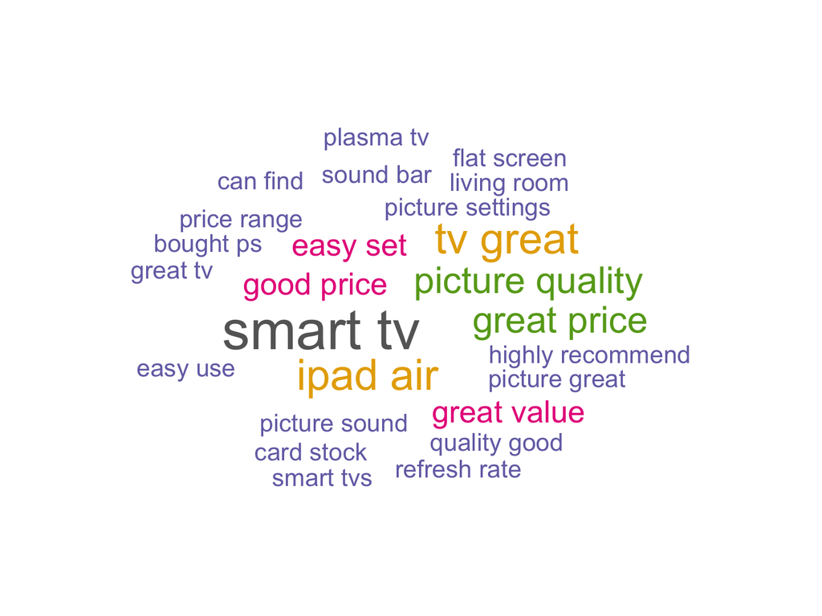

## Ngrams for worst pricing sentiment score products

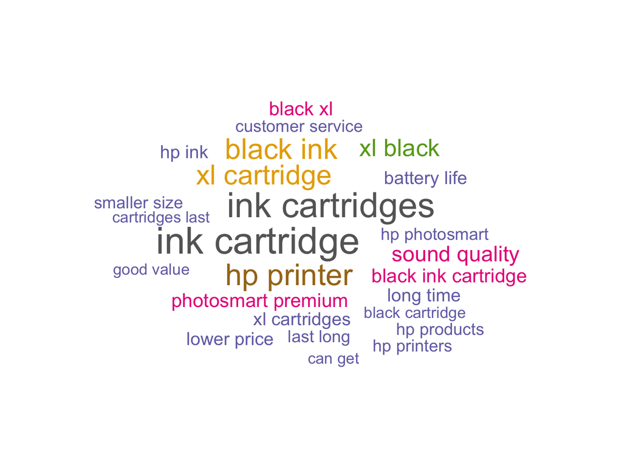

## Words for best pricing sentiment score products

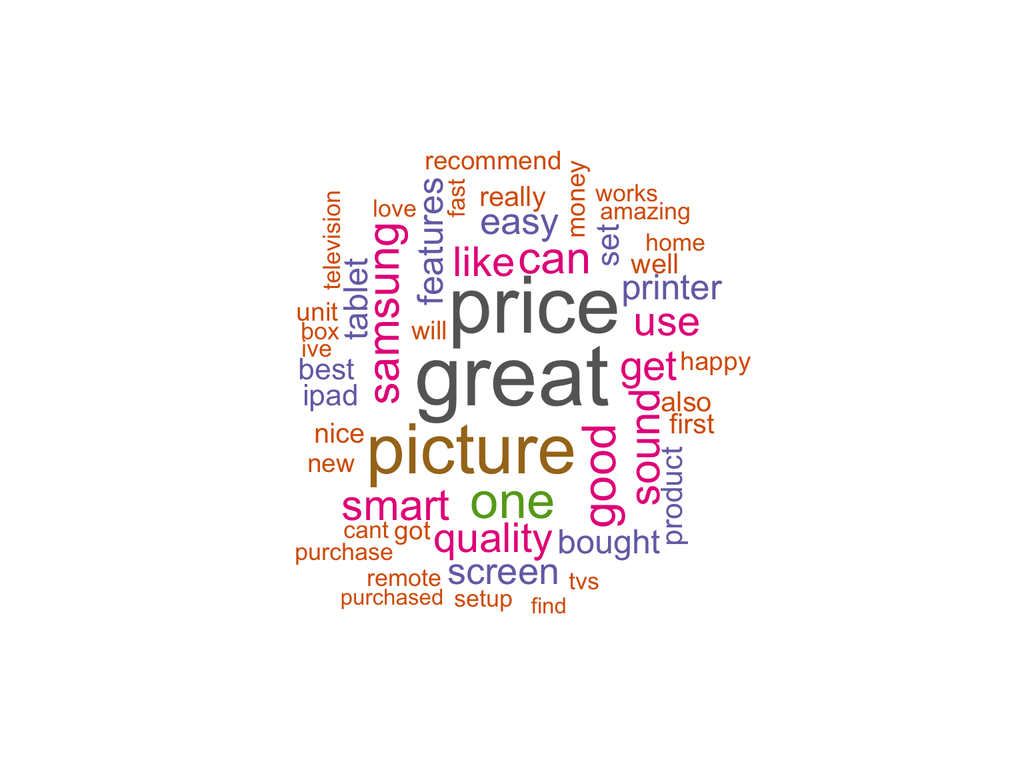

## Words for worst pricing sentiment score products

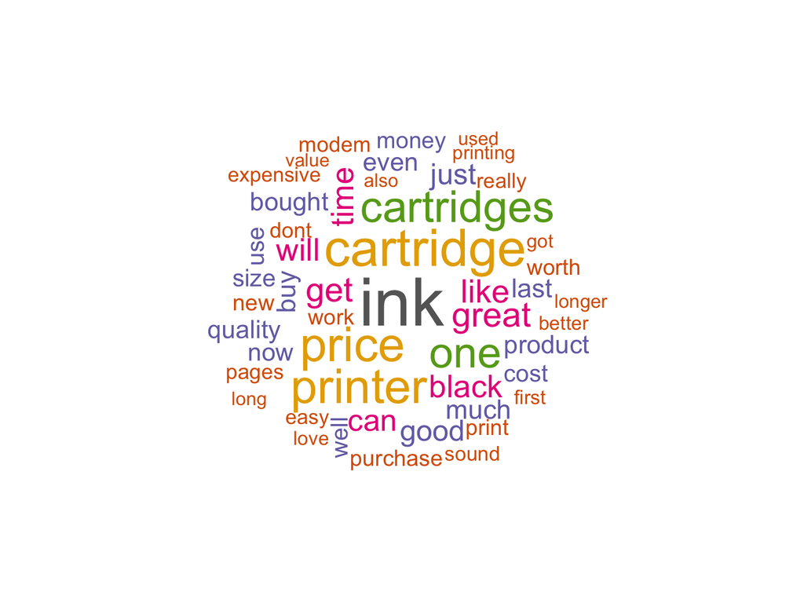

## Correlations between product ratings and pricing sentiment

| wmt_product_name | wmt_product_id | correlation |
| --- | --- | --- |
| VIZIO E400i-B2 40“” 1080p 120Hz Full-Array LED Smart HDTV | 33054851 | 0.4603 |
| HP Consumables CN684WN#140 564XL Black Ink | 20657638 | 0.4518 |
| ARRIS/Motorola SBG6580 SURFboard DOCSIS 3.0 Cable Modem and WiFi-N Router | 15567546 | 0.3955 |
| NETGEAR WNDR3400-100NAS N600 Wireless Dual Band Router | 15539745 | 0.3751 |
| Samsung 32“” 1080p 60Hz LED Smart HDTV, UN32H5203AFXZA | 36483178 | 0.3599 |
| Fitbit Flex Wireless Activity Sleep Band | 26469465 | 0.3152 |
| HP 61 Black/Tri-color Original Ink Cartridges, 2 pack (CR259FN) | 15084439 | 0.1927 |
| Samsung Galaxy Tab S 10.5“” Tablet 16GB | 37065363 | 0.1499 |
| Google H2G2-42 HDMI Streaming Media Player - Wi-Fi - 1080p - Netflix, YouTube, HBO GO, Hulu Plus - Black | 33142918 | 0.148 |
| Roku Streaming Stick, 3500R with Get 60 days FREE* of Rdio Unlimited and Try 3 months FREE of Hulu Plus | 35030305 | 0.1414 |
| Samsung Galaxy Tab 4 7.0“” Tablet 8GB | 35822395 | 0.1304 |
| ZZ Motorola 575319-019-00 SURFboard Docsis 3.0 Cable Mod | 20742485 | 0.07075 |
| Samsung 40“” 1080p 60Hz LED HDTV, UN40H5003AFXZA | 39405700 | 0.05769 |
| Samsung 40“” 1080p 60Hz LED Smart HDTV, UN40H5203AFXZA | 36483179 | -0.06063 |

## Example of relatively strong correlation between rating and sentiment

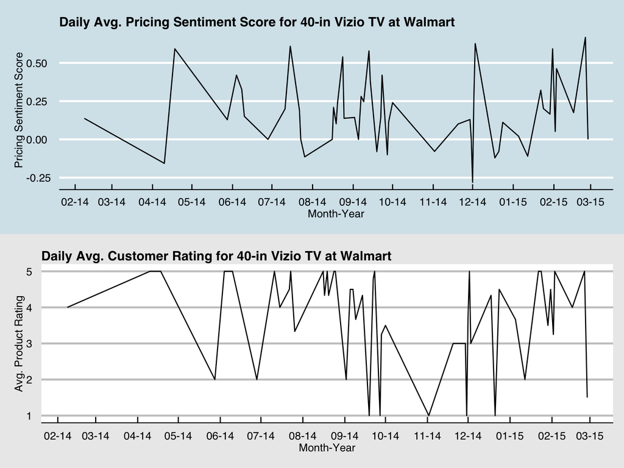

## Example of a weak correlation between rating and sentiment

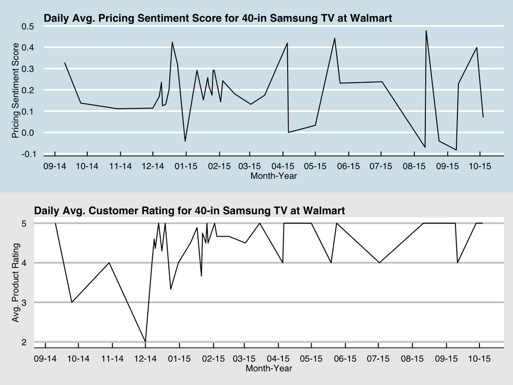